# Clust_markdown

```r
setwd("/Users/sobia/Applied_Data")
library(dplyr)
Hw_data_cluster=read.csv("Hw_Data.csv", sep = ";")
colnames(Hw_data_cluster)
```

```
##  [1] "id"                  "battery_power"       "bluetooth"
##  [4] "clock_speed"         "dual_sim"            "f_camera"
##  [7] "four_g"              "int_memory"          "mob_depth"
## [10] "mobile_weight"       "num_cores_processor" "primry_cam"
## [13] "ram"                 "screen_height"       "screen_weight"
## [16] "talk_time"           "three_g"             "touch_screen"
## [19] "wifi"                "Seller_name"
```

A model-based approach to determine the optimal number of clusters

```r
Numeric_data=Hw_data_cluster %>%select(int_memory, primry_cam, num_cores_processor)
Numeric_data
```

```
##      int_memory primry_cam num_cores_processor
## 1             5         16                   3
## 2            61         12                   5
## 3            27          4                   3
## 4            25         20                   8
## 5            49         18                   6
## 6            50          9                   8
## 7            47          3                   2
## 8            62          2                   1
## 9            25         19                   5
## 10           25         20                   3
## 11           55          6                   7
## 12           34          6                   3
## 13           30          3                   2
## 14           19         15                   5
```

[output cut: 986 more lines]

```r
library(mclust)
M_clust_1=Mclust(Numeric_data)
M_clust_1
```

```
## 'Mclust' model object: (EVI,8)
##
## Available components:
##  [1] "call"           "data"           "modelName"      "n"
##  [5] "d"              "G"              "BIC"            "loglik"
##  [9] "df"             "bic"            "icl"            "hypvol"
## [13] "parameters"     "z"              "classification" "uncertainty"
```

```r
M_clust_2= Mclust(Numeric_data, G = 5)
M_clust_2
```

```
## 'Mclust' model object: (EVI,5)
##
## Available components:
##  [1] "call"           "data"           "modelName"      "n"
##  [5] "d"              "G"              "BIC"            "loglik"
##  [9] "df"             "bic"            "icl"            "hypvol"
## [13] "parameters"     "z"              "classification" "uncertainty"
```

```r
M_clust_3=Mclust(Numeric_data, G = 6)
M_clust_3
```

```
## 'Mclust' model object: (EVI,6)
##
## Available components:
##  [1] "call"           "data"           "modelName"      "n"
##  [5] "d"              "G"              "BIC"            "loglik"
##  [9] "df"             "bic"            "icl"            "hypvol"
## [13] "parameters"     "z"              "classification" "uncertainty"
```

```r
M_clust_4=Mclust(Numeric_data, G = 7)
M_clust_4
```

```
## 'Mclust' model object: (EVI,7)
##
## Available components:
##  [1] "call"           "data"           "modelName"      "n"
##  [5] "d"              "G"              "BIC"            "loglik"
##  [9] "df"             "bic"            "icl"            "hypvol"
## [13] "parameters"     "z"              "classification" "uncertainty"
```

```r
M_clust_5=Mclust(Numeric_data, G = 2)
M_clust_5
```

```
## 'Mclust' model object: (EEI,2)
##
## Available components:
##  [1] "call"           "data"           "modelName"      "n"
##  [5] "d"              "G"              "BIC"            "loglik"
##  [9] "df"             "bic"            "icl"            "hypvol"
## [13] "parameters"     "z"              "classification" "uncertainty"
```

```r
M_clust_6=Mclust(Numeric_data, G = 3)
M_clust_6
```

```
## 'Mclust' model object: (VVI,3)
##
## Available components:
##  [1] "call"           "data"           "modelName"      "n"
##  [5] "d"              "G"              "BIC"            "loglik"
##  [9] "df"             "bic"            "icl"            "hypvol"
## [13] "parameters"     "z"              "classification" "uncertainty"
```

```r
M_clust_7=Mclust(Numeric_data, G = 4)
M_clust_7
```

```
## 'Mclust' model object: (EVI,4)
##
## Available components:
##  [1] "call"           "data"           "modelName"      "n"
##  [5] "d"              "G"              "BIC"            "loglik"
##  [9] "df"             "bic"            "icl"            "hypvol"
## [13] "parameters"     "z"              "classification" "uncertainty"
```

```r
BIC_comparison=BIC(M_clust_1,M_clust_2,M_clust_3,M_clust_4,M_clust_5,M_clust_6, M_clust_7)
M_clust_classi=M_clust_1$classification
M_clust_classi
```

[output not shown]

```r
set.seed(100)
k_m_1=kmeans(as.matrix(Numeric_data),centers = 2)
k_m_2=kmeans(as.matrix(Numeric_data),centers = 3)
k_m_3=kmeans(as.matrix(Numeric_data),centers = 4)
k_m_4=kmeans(as.matrix(Numeric_data),centers = 5)
k_m_5=kmeans(as.matrix(Numeric_data),centers = 6)
k_m_6=kmeans(as.matrix(Numeric_data),centers = 7)
k_m_7=kmeans(as.matrix(Numeric_data),centers = 8)

k_m_7_clu=k_m_7$cluster
k_m_7_clu
```

[output not shown]

```r
library(tidyverse)
library(magrittr)
ssc=data.frame(kmeans = c(2,3,4,5,6,7,8),
  within_ss = c(mean(k_m_1$withinss), mean(k_m_2$withinss), mean(k_m_3$withinss), mean(k_m_4$withinss), mean(k_m_5$withinss), mean(k_m_6$withinss), mean(k_m_7$withinss)),
  between_ss = c(k_m_1$betweenss,k_m_2$betweenss,k_m_3$betweenss, k_m_4$betweenss,k_m_5$betweenss, k_m_6$betweenss,k_m_7$betweenss)
)
ssc
```

```
##   kmeans within_ss between_ss
## 1      2 63812.738   243038.9
## 2      3 26514.959   291119.5
## 3      4 15421.181   308979.7
## 4      5 10756.406   316882.4
## 5      6  7670.354   324642.3
## 6      7  5530.288   331952.4
## 7      8  4167.107   337327.5
```

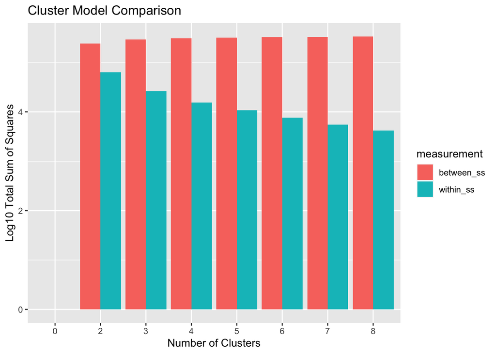

```r
ssc %<>% gather(., key = "measurement", value = value, -kmeans)
ssc %>% ggplot(., aes(x=kmeans, y=log10(value), fill = measurement)) + geom_bar(stat = "identity", position = "dodge") + ggtitle("Cluster Model Comparison") + xlab("Number of Clusters") + ylab("Log10 Total Sum of Squares") + scale_x_discrete(name = "Number of Clusters", limits = c("0", "2", "3", "4", "5", "6", "7", "8"))
```

the graph shows that with 7 and 8 clusters, /“between sum of squares stays the same”/, but /“within sum of square”/ decreases.here my goal is to choose the lowest sum of squares, therefore, the optimal number of clusters are 8, so, I decided to choose 8 clusters.

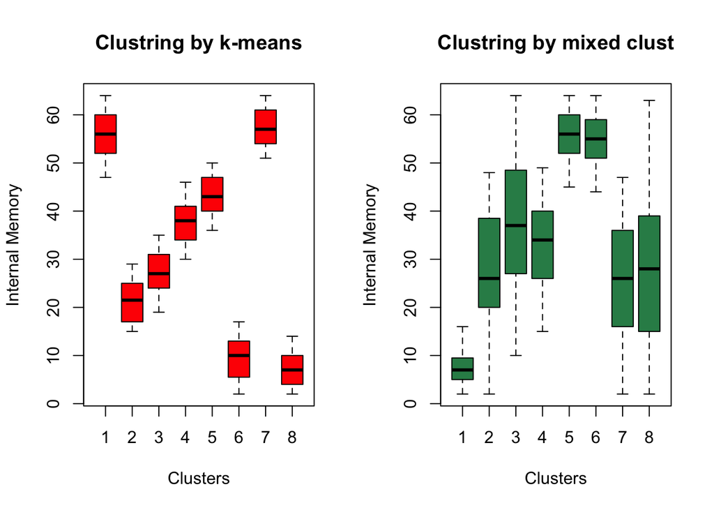

```r
par(mfrow = c(1,2))
boxplot(Numeric_data$int_memory~ k_m_7_clu, ylab = "Internal Memory", xlab = "Clusters", col = "red", main = "Clustring by k-means")
boxplot(Numeric_data$int_memory ~ M_clust_classi, ylab = "Internal Memory", xlab = "Clusters", col = "seagreen", main = "Clustring by mixed clust")
```

Based on the box plots, I choose k-means. I think it is better because clusters are similar to each other. but in mixed they differ a lot.

Compariosn of k-means and mixed_Clust for primary_cam

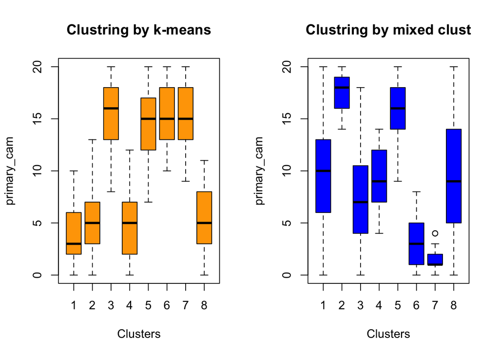

```r
par(mfrow = c(1,2))
boxplot(Numeric_data$primry_cam~ k_m_7_clu, ylab = "primary_cam", xlab = "Clusters", col = "orange", main = "Clustring by k-means")
boxplot(Numeric_data$primry_cam ~ M_clust_classi, ylab = "primary_cam", xlab = "Clusters", col = "blue", main = "Clustring by mixed clust")
```

```r
Anova_test=aov(Numeric_data$int_memory~k_m_7$cluster)
summary(Anova_test)
```

```
##                Df Sum Sq Mean Sq F value Pr(>F)
## k_m_7$cluster   1  21751   21751   70.81 <2e-16 ***
## Residuals     998 306570     307
## ---
## Signif. codes:  0 '***' 0.001 '**' 0.01 '*' 0.05 '.' 0.1 ' ' 1
```

At the 5% significance level the clusters cannot be considered as equal in amounts of factors.because p-value is very low number, thus we reject null hypothesis and conclude that there is the values of the numeric variable significantly differ across the categories of the factor (clusters) in the population

```r
front_camera_num=as.numeric(Hw_data_cluster$f_camera)
front_camera_cat=cut(front_camera_num, breaks = c(0, 5, 10, 15, 20))
Hw_data_cluster$category[Hw_data_cluster$f_camera >=0 & Hw_data_cluster$f_camera<5] = "1"
Hw_data_cluster$category[Hw_data_cluster$f_camera >=5 &Hw_data_cluster$f_camera <10] = "2"
Hw_data_cluster$category[Hw_data_cluster$f_camera>=10 &Hw_data_cluster$f_camera<15] = "3"
Hw_data_cluster$category[Hw_data_cluster$f_camera>=15 &Hw_data_cluster$f_camera<=20] = "4"
Hw_data_1=Hw_data_cluster %>%select(int_memory, primry_cam, num_cores_processor,category)
Hw_data_1
```

```
##      int_memory primry_cam num_cores_processor category
## 1             5         16                   3        3
## 2            61         12                   5        1
## 3            27          4                   3        1
## 4            25         20                   8        4
## 5            49         18                   6        3
## 6            50          9                   8        2
## 7            47          3                   2        1
## 8            62          2                   1        1
## 9            25         19                   5        2
## 10           25         20                   3        1
## 11           55          6                   7        1
## 12           34          6                   3        1
## 13           30          3                   2        1
## 14           19         15                   5        2
```

[output cut: 986 more lines]

Part 2——

[figure not shown]

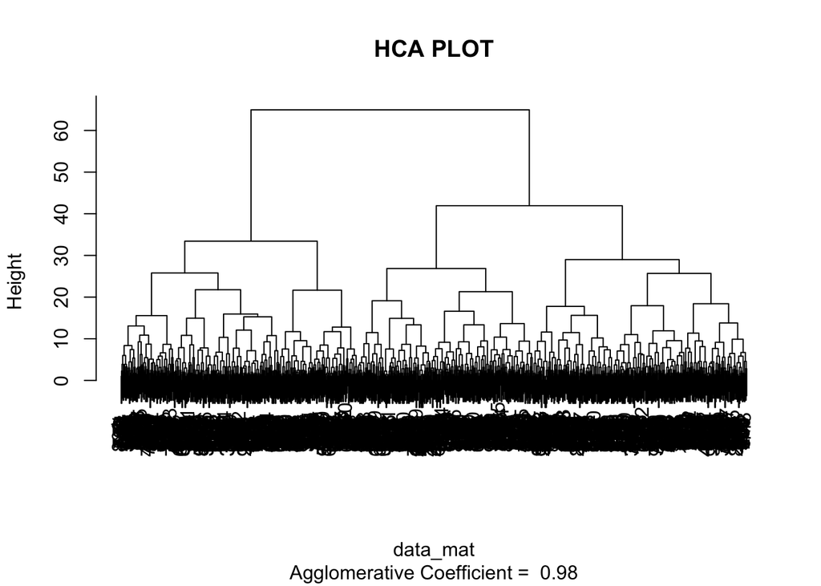

```r
library(cluster)
data_mat=data.matrix(Hw_data_1, rownames.force = NA)
data_hca=agnes(data_mat,method="complete",keep.diss = T, metric = "Gower")
plot(data_hca, main="HCA PLOT")
```

plot of HCA

```r
data_hca.clu4=cutree(data_hca, 4)
data_hca.clu4
```

[output not shown]

[figure not shown]

```r
catag_data=table(Hw_data_cluster[4])
comb_data=cbind(catag_data,data_hca.clu4)
chisq.test(comb_data)
```

```
##
##  Pearson's Chi-squared test
##
## data:  comb_data
## X-squared = 260.78, df = 999, p-value = 1
```

chi-square test shows that p -value = 1 is higher than significance level 5%. Thus, I cannot reject null hypothesis. So I conclude that there is independence of categorical variable